# PROJECTE ANÀLISI DE DADES: Entrada Turística Espanya

David Anglada Rotger i Andreu Huguet Segarra

17/5/2019

# Introducció

# Identificació

## Representació gràfica de les dades

Un cop feta la representació de les dades, s’observa una clara tendència creixent. Tot i així, aquesta tendència no és constant, ja que és menys pronunciada entre els anys 2000 i 2010, fins i tot amb una petita baixada entre els anys 2007i 2010 i sembla que es pronuncia a partir de l’any 2011.

Pel que fa a la variància, s’observa que va augmentant a mesura que augmenta la mitjana dels valors de les dades, és a dir, a mesura que es pronuncia la tendència creixent. És a dir, en els anys 2000-2010, la variància és menor que en els anys 2011-2019, on el creixement augmenta.

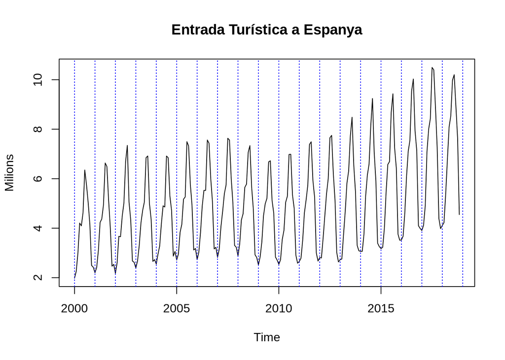

### Descomposició en components bàsiques

Per poder analitzar millor les dades, es realitza la seva descomposició en les seves components bàsiques, és a dir, el model aditiu de la serie:

$$X_t = T_t + S_t + C_t + \omega_t$$
on: - $T_t$ és la **tendència** de la sèrie a llarg termini. - $S_t$ és el *seasonal* de la sèrie (patró repetit periòdicament amb període constant). - $C_t$ és el **cicle** de la sèrie (patró repetit periòdicament amb període no constant). Aquesta part no surt representada en la descomposició. - $\omega_t$ és el soroll aleatòri.

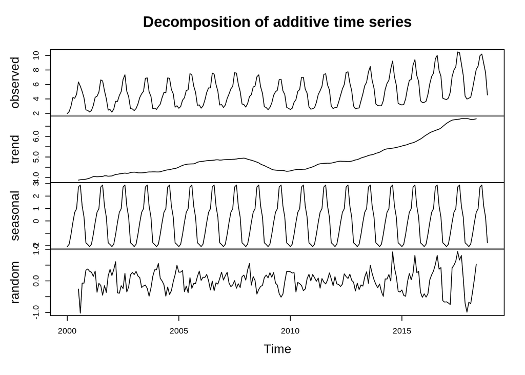

S’observa, tal i com s’havia comentat anteriorment, la clara tendència creixent de la sèrie, amb un creixement menys pronunciat a l’inici, una petita baixada entre els anys 20017 i 2010 i una pujada més pronunciada més cap a l’actualitat. Pel que fa al patró estacional, observem que durant els mesos d’estiu, el número de turistes a Espanya augmenta molt considerablement. Aquest fet que no crida l’atenció, ja que és durant els mesos d’estiu quan més vacanses s’agafa la gent i més aprofiten per venir a les costes espanyoles. Durant els mesos de tardor-hivern, observem que el número de turistes cau en picat.

## Transformació de les dades

A continuació s’analitzarà la necessitat de realitzar una sèrie de transformacions amb l’objectiu d’aconseguir estacionaritat en la nostra sèrie temporal.

### Variància constant

En primer lloc, s’estudiarà si es pot considerar que la variància de les dades sigui constant en el temps. Ja s’ha comentat que a simple vista semblava que no. Tot i així es comprova amb un plot de la variància front la mitjana i un *boxplot* de les dades cada 12 mesos (que és la freqüència de les nostres dades).

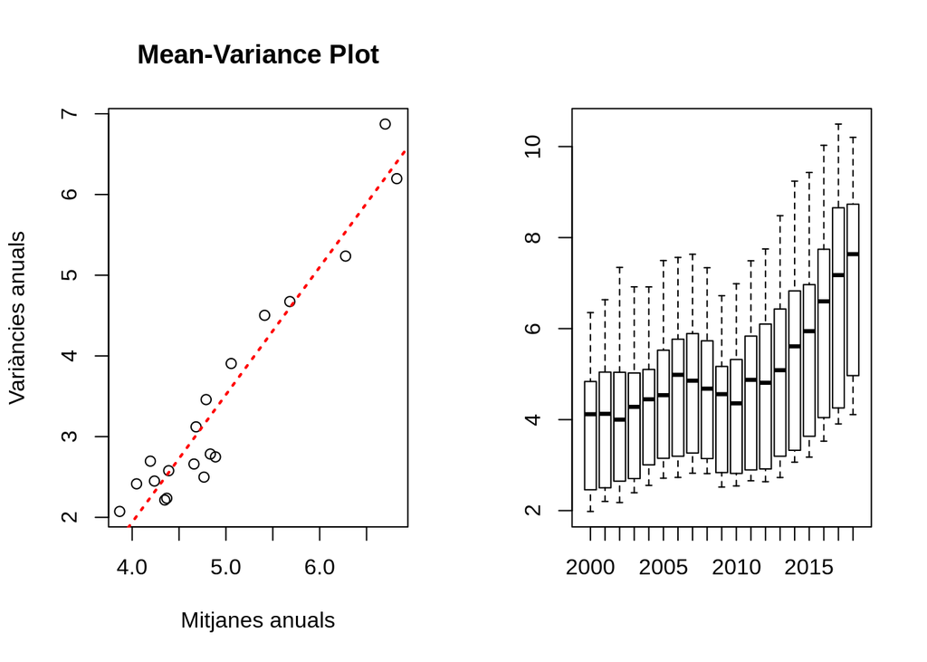

Tal i com s’havia observat a simple vista, la variància augmenta a mesura que agumenta la mitja. Per tant, no podem assumir variància constant. Amb el *boxplot* es confirma aquesta hipòtesis. Així doncs, es procedeix a realitzar una transformació logarítmica de la sèrie per homogeneïtzar la variància. Els resultats obtinguts són els següents:

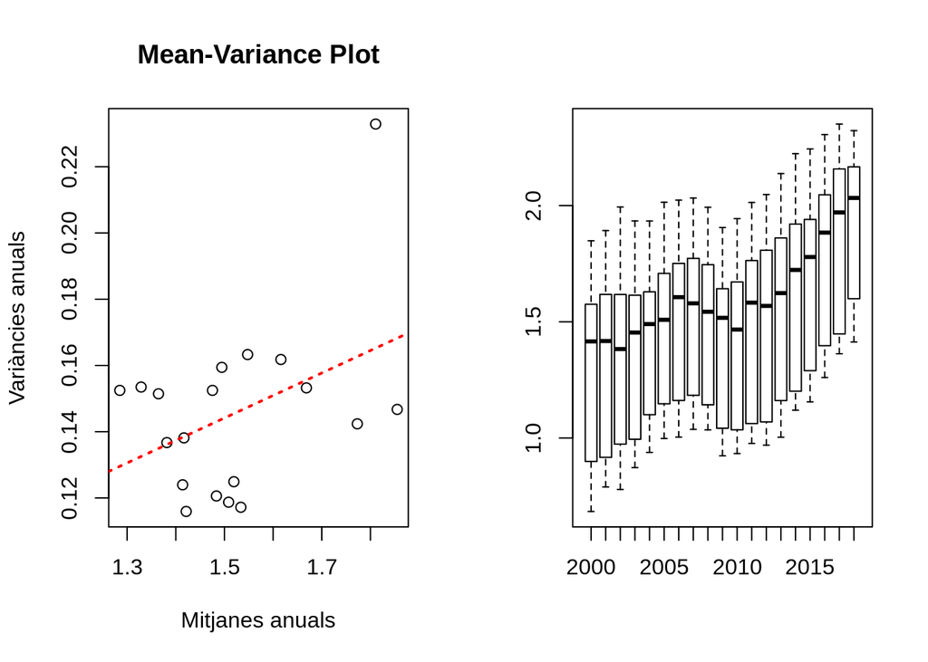

S’observa que la variància s’ha homogeneïtzat, és a dir, ja es pot considerar constant.

### Patró estacional

En segon lloc, s’estudiarà l’existència d’un patró estacional en les nostres dades. En cas que hi sigui present, es realitzarà una diferenciació d’ordre 12, és a dir,

$$W_t = X_t - X_{t-12} = (1 - B^{12})X_t$$
on $B$ és el *backshift operator*, per eliminar aquest patró. Es realitza un *monthplot* per comprovar-ne l’existència.

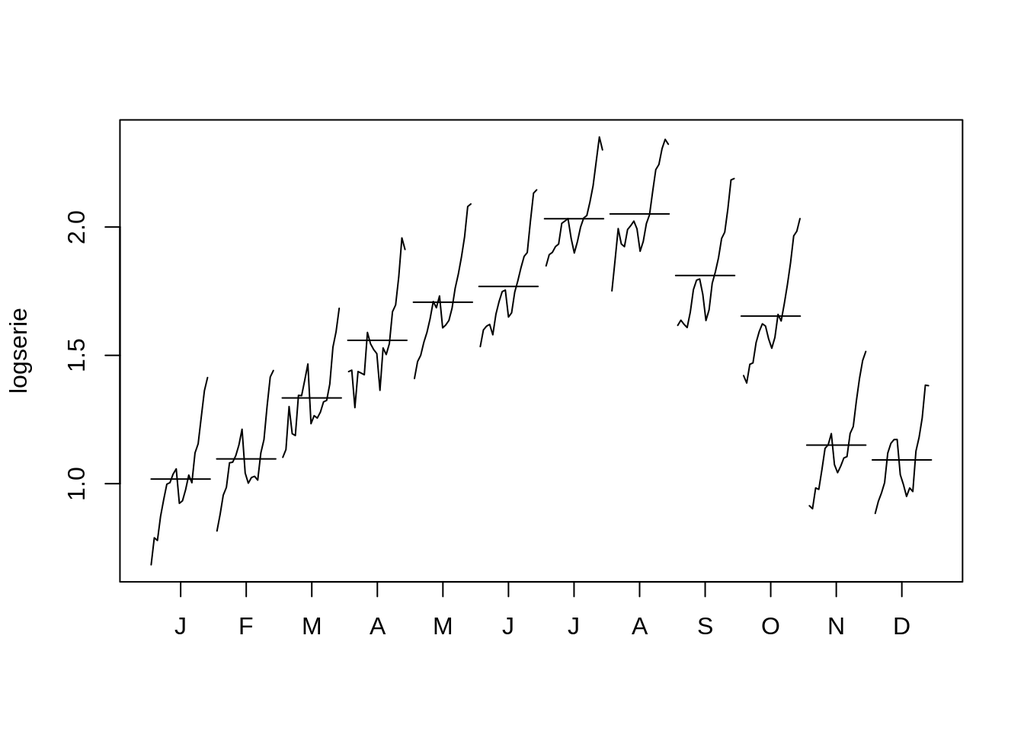

Tal i com s’havia comenta, s’observa una clara pujada de la presència de turistes durant els mesos d’estiu i una baixada en picat en l’entrada de l’hivern/tardor. Així doncs, és necessària una diferenciació d’ordre 12 per eliminar aquest patró.

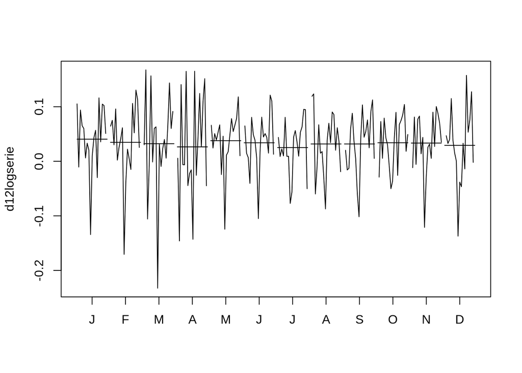

S’observa que amb una diferenciació d’ordre 12 s’ha eliminat el patró estacional. Ara bé, la mitjana de la sèrie encara no és constant.

### Mitjana constant

Per últim, es vol aconseguir que la sèrie tingui mitjana constant igual (i si és possible igual a 0) per a poder considerar definitivament la sèrie com un procés estacionari. Per aconseguir-ho, es realitzaran diferenciacions regulars de la sèrie fins que s’obtingui el resultat desitjat

$$W_t = X_t - X_{t-1} = (1 - B)X_t$$

Es realitza la primera diferenciació. Els valors de mitjana i variància aconseguits són els seguents:

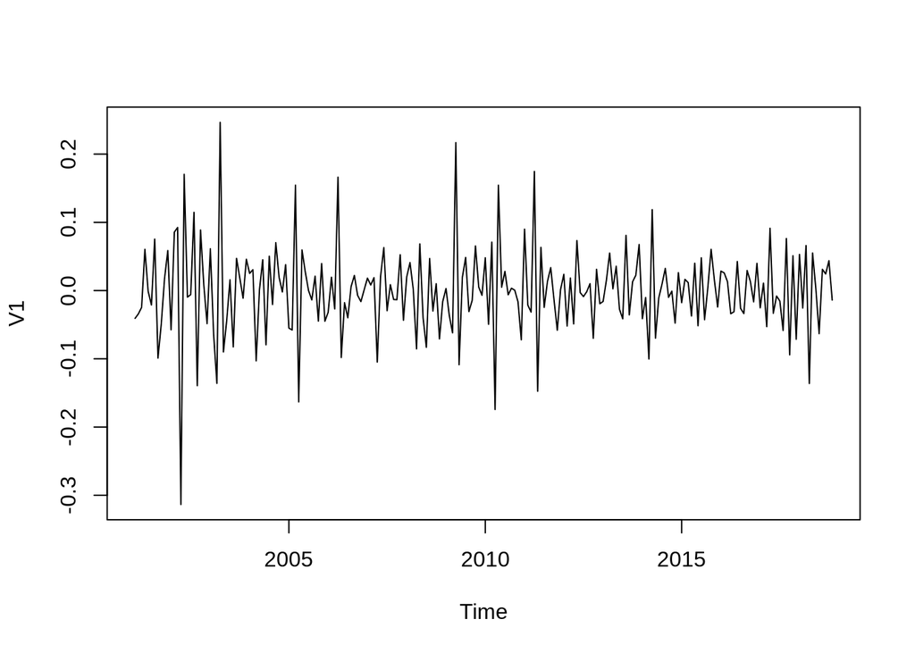

```
## [1] -0.0003272785
```

```
##             V1
## V1 0.004266965
```

Com es pot observar, la mitjana del procés diferenciat regularment un cop es pot considerar constant i nula. Ara bé, es mira de diferenciar un segon cop i s’observa que la variància augmenta i, per tant, es té *overdifferentiation*.

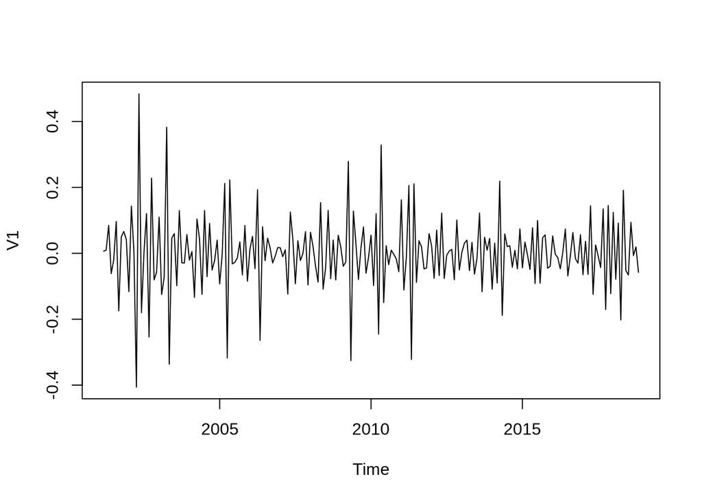

```
## [1] 0.0001260592
```

```
##           V1
## V1 0.0132293
```

En definitiva, la sèrie transformada pel logaritme, diferenciada un cop i amb una diferenciació d’ordre 12 per eliminar el patró estacional ($\texttt{d1d12logserie}$) és un procés estacionari de mitjana 0.

## ACF/PACF de les dades i proposta de models

Tot seguit, es realitza un anàlisi de les funcions *AutoCorrelació* i de *Correlació Parcial* de la sèrie transformada, és a dir, de la sèrie estacionària.

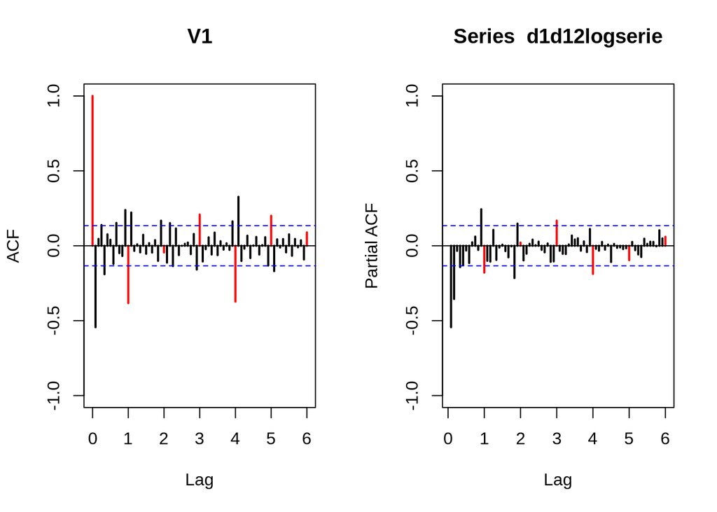

### Models proposats per la part regular (p,d,q)

En relació a la part regular de la sèrie, en la funció d’AutoCorrelació (ACF) s’observa que només sobresurt el primer valor. La resta de valors es poden considerar nuls, ja que o bé estan dintre de l’interval de confiança, o bé es poden assignar al cas d’aleatorietat del 5%. Per tant, per la part regular, es proposaria $q=1$.

Pel que fa a la funció de Correlació Parcial (PACF) s’observa un decreixement exponencial dels primers valors. S’observen també valors fora de la banda de confiança, però poden ser assignats a la aleatorietat del cas 5%. Per tant, en aquest cas, es proposaria $p=0$. En tot cas, si es volgués mirar d’incloure el primer valor que sobresurt més que la resta, es podria considerar també $p=1$.

Donat que s’ha realitzat diferenciació 1 cop, es té que $d=1$. Per tant, els models proposats per la part regular serien $MA(1)$ o, en tot cas, $ARMA(1,1)$ sobre la sèrie transformada regular.

## Models proposats per la part estacional (P,D,Q)

En relació a la part estacional de la sèrie, en la funció d’AutoCorrelació (ACF) s’observa que el primer valor es força significatiu, però també ho són el tercer, el quart i el cinquè, sobretot el quart. Donat que volem intentar proposar un model simplificat, es proposa $Q=0$.

Pel que fa a la funció de Correlació Parcial (PACF) s’observa que sobresurt el primer valor una mica i també sobresurten el tercer i el quart valor. Ara bé, no sobresurten de manera tant significativa com en el cas dels valors del ACF i, per tant, podem assignar-ho al cas d’aleatorietat del 5%. Per tant, en aquest cas, es proposaria $P=1$.

## Models proposats

En conclusió, es proposen per la sèrie diferenciada els models estacionals:

-$ARMA(0,1)(1,0)_s$ -$ARMA(1,1)(1,0)_s$

I per la sèrie original, tenint en compte les diferenciacions, es proposen:

-$ARIMA(0,1,1)(1,1,0)_s$ -$ARIMA(1,1,1)(1,1,0)_s$

# Estimació dels models

# Validació dels Models

## Estabilitat dels Models

# Previsions a llarg termini

# Tractament de *outliers*